# Post Goals:

# Visualizing the Chi-Square Probability Density Function

**Why we plot the Probability Density Function (PDF)**

- The Probability density function gives the probability of a given value will occur.
- Visualizing PDF gives a graphically portrayed off a given probability and the area under the curve will indicate the interval in which the variable will fall.
- The probability density plot is used to understand the data distribution for a given variable and we want to know the likelihood (or probability) of obtaining a range of values that the variable can assume.

**How to plot PDF using python scipy (v1.6.3) and matplotlib.**

```python
from scipy.stats import chi2
import matplotlib.pyplot as plt
import numpy as np
```

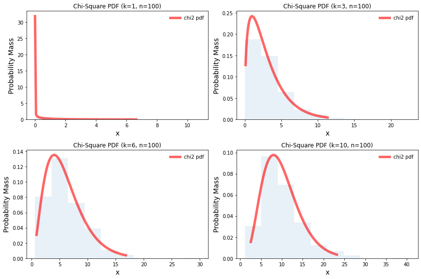

```python
degrees_of_freedom = [1, 3, 6, 10] # the degrees of freedom
fig = plt.figure(figsize=(12,8))
for df, num in zip(degrees_of_freedom, range(1,5)):

    ax = fig.add_subplot(2,2, num)
    x = np.linspace(chi2.ppf(0.01, df), chi2.ppf(0.99, df), 100)
    ax.plot(x, chi2.pdf(x, df), 'r-', lw=5, alpha=0.6, label='chi2 pdf')
    rv = chi2(df)
    vals = chi2.ppf([0.001, 0.5, 0.999], df)
    r = chi2.rvs(df, size=1000)
    ax.hist(r, density=True, histtype='stepfilled', alpha=0.1)
    ax.legend(loc='best', frameon=False)
    ax.set_ylabel('Probability Mass', fontsize=14)
    ax.set_xlabel('x', fontsize=14)
    ax.set_title(f"Chi-Square PDF (k={df}, n={len(x)})")

plt.tight_layout()
plt.show()
```